# ShinyPresentation

20/02/2020

## Analysis of sncf train dashboards

we will divide the presentation in 3 parts:

- Part 1 : Presenation of the dataset and some results
- Part 2 : Explanation of this shiny application
- Part 3 : Presentaion of some plots and the links

## Part 1 : Presentation of the dataset

```
##       year          month          service          departure_station
##  Min.   :2015   Min.   : 1.000   Length:5462        Length:5462
##  1st Qu.:2016   1st Qu.: 3.000   Class :character   Class :character
##  Median :2017   Median : 6.000   Mode  :character   Mode  :character
##  Mean   :2017   Mean   : 6.369
##  3rd Qu.:2018   3rd Qu.: 9.000
##  Max.   :2018   Max.   :12.000
##
##  arrival_station    journey_time_avg total_num_trips num_of_canceled_trains
##  Length:5462        Min.   : 45.96   Min.   :  6.0   Min.   :  0.000
##  Class :character   1st Qu.:100.77   1st Qu.:181.0   1st Qu.:  0.000
##  Mode  :character   Median :160.84   Median :238.0   Median :  1.000
##                     Mean   :165.39   Mean   :281.1   Mean   :  7.737
##                     3rd Qu.:205.70   3rd Qu.:390.0   3rd Qu.:  4.000
##                     Max.   :481.00   Max.   :878.0   Max.   :279.000
##
##  comment_cancellations num_late_at_departure avg_delay_late_at_departure
##  Mode:logical          Min.   :  0.00        Min.   :  0.00
##  NA's:5462             1st Qu.: 10.00        1st Qu.: 11.98
##                        Median : 23.00        Median : 15.84
##                        Mean   : 41.58        Mean   : 16.81
##                        3rd Qu.: 51.75        3rd Qu.: 20.28
##                        Max.   :451.00        Max.   :173.57
##
##  avg_delay_all_departing comment_delays_at_departure num_arriving_late
##  Min.   : -4.468         Mode:logical                Min.   :  0.00
##  1st Qu.:  0.896         NA's:5462                   1st Qu.: 17.00
##  Median :  1.783                                     Median : 30.00
##  Mean   :  2.539                                     Mean   : 38.03
##  3rd Qu.:  3.243                                     3rd Qu.: 50.00
##  Max.   :173.571                                     Max.   :235.00
##                                                      NA's   :9
##  avg_delay_late_on_arrival avg_delay_all_arriving comment_delays_on_arrival
##  Min.   :  0.00            Min.   :-143.969       Length:5462
##  1st Qu.: 23.81            1st Qu.:   2.706       Class :character
##  Median : 30.76            Median :   4.581       Mode  :character
##  Mean   : 32.45            Mean   :   5.287
##  3rd Qu.: 38.77            3rd Qu.:   7.252
##  Max.   :258.00            Max.   :  36.817
##  NA's   :9
```

[output cut: 17 more lines]

```
##  Min.   :0.00000                Min.   :0.00000       Min.   :  0.00
##  1st Qu.:0.00000                1st Qu.:0.00000       1st Qu.: 11.00
##  Median :0.05263                Median :0.02128       Median : 20.00
##  Mean   :0.06999                Mean   :0.03730       Mean   : 26.09
##  3rd Qu.:0.10256                3rd Qu.:0.05769       3rd Qu.: 35.00
##  Max.   :1.00000                Max.   :0.66667       Max.   :192.00
##  NA's   :170                    NA's   :170           NA's   :5
##  avg_delay_late_greater_15_min num_greater_30_min_late num_greater_60_min_late
##  Min.   :-118.022              Min.   : 0.00           Min.   : 0.000
##  1st Qu.:   8.994              1st Qu.: 4.00           1st Qu.: 1.000
##  Median :  31.533              Median : 9.00           Median : 3.000
##  Mean   :  28.984              Mean   :11.65           Mean   : 4.197
##  3rd Qu.:  41.000              3rd Qu.:16.00           3rd Qu.: 6.000
##  Max.   : 258.000              Max.   :91.00           Max.   :36.000
##  NA's   :5                     NA's   :5               NA's   :5
```

## Part 2 : Explanation of this shiny application

Composition of the application: Two parts: UI for interface and SERVER for the manipulation of the application.

The UI part contents some filters which are used to refine the data presented in the application.

The Server part contents some functions such as the aggregations functions and also some reactive variables ( render*) that have the property to refresh when necessary.

## Source Code

[output not shown]

Shiny applications not supported in static R Markdown documents

## Part 3 : Presentaion of some plots

## Plots of the average delay late on arrival per year

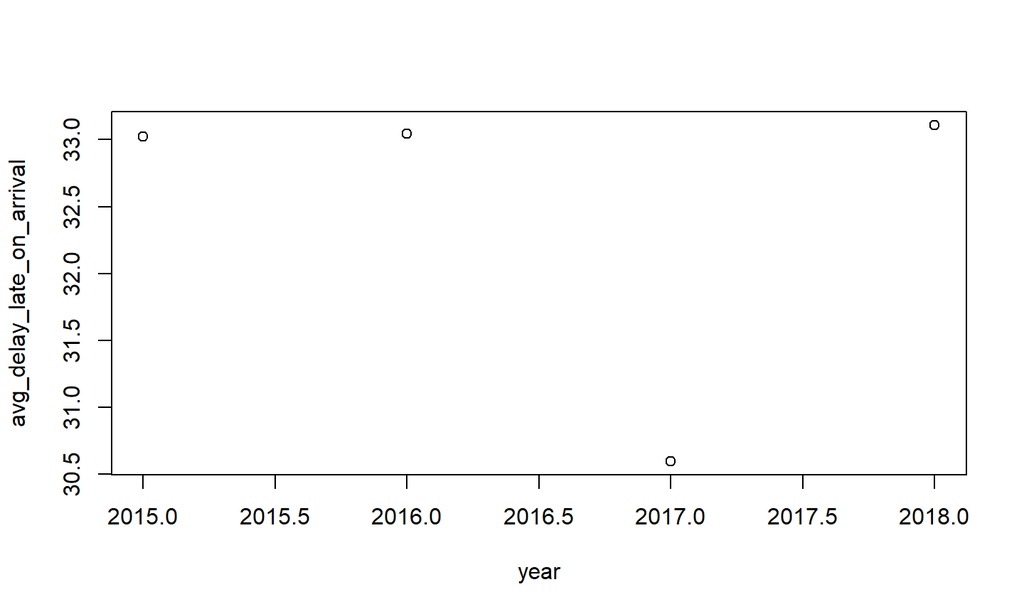

## links

```
## [1] "https://aminagb.shinyapps.io/Rshiny_Project_Train/"
```

```
## [1] "https://github.com/AminaHadi/Shiny_Project/"
```

```
## [1] "https://aminagb.shinyapps.io/ShinyPresentation.Rmd/"
```